# Impact of information framing on trustworthiness

Kilian Sennrich

7 9 2020

# Exploration

## Balance check

For propper analysis, it is important, that demographic factors are well balanced between the two Conditions “Positive Frame” & “Negative Frame”

**Age**

```
##
##  Wilcoxon rank sum test with continuity correction
##
## data:  data[Condition == "PositiveFrame"]$Age and data[Condition == "NegativeFrame"]$Age
## W = 1137, p-value = 0.2119
## alternative hypothesis: true location shift is not equal to 0
```

Mann Withney U Test was used to see, whether age distribution significantly differs between the two Conditions. This was not the case

**Gender**

```
##
##  Pearson's Chi-squared test
##
## data:  table(data$Condition, factor(data$Gender))
## X-squared = 3.4387, df = 2, p-value = 0.1792
```

Chi-squared test was used to see, whether the Genders were equivalently represented between the two Conditions. This was the case.

**Trust in Stranger**

```
##
##  Wilcoxon rank sum test with continuity correction
##
## data:  data[Condition == "PositiveFrame"]$TrustInStranger and data[Condition == "NegativeFrame"]$TrustInStranger
## W = 1404, p-value = 0.5846
## alternative hypothesis: true location shift is not equal to 0
```

Mann Withney U Test was used to see, whether people in both conditions generally trust the same in stranger. This is the case here.

## Understanding of the Experiment

Understanding of the experiment was good. On Average 5.6 out of 7 Points were given by the subjects for the understanding of ones task and the understanding of the description. High correlation between the items is expected. In fact 72 of the 103 subjects (~70%) chose the same answer for both of the items.

```
##           Min. 1st Qu. Median     Mean 3rd Qu. Max.
## UnderDesc    2       5      6 5.563107       7    7
## UnderRole    2       5      6 5.621359       7    7
```

```
##          UnderRole
## UnderDesc  2  3  4  5  6  7
##         2  2  1  0  0  0  0
##         3  0  4  1  2  0  0
##         4  0  0  5  2  2  0
##         5  0  0  3 15  3  0
##         6  0  1  0  3 24  8
##         7  0  1  0  0  4 22
```

```
## [1] 0.8112831
```

# Analysis

## Correlation Table

Item titles are systematic. Numbers 1 or 2 indicate measurement repetition. Repeated items are considered to correlate. Magnitude of correlation can be used as an indication of the reliability of item formulation. In the following, a correlation table can be found, which includes p.value and correlation. The reliability of the different items is not uniform. A correlation of just under 0.5 can be rated as very low, whereas a correlation of 0.8 seems definitely sufficient. For further analysis, repeated measurements will be combined (rounded mean).

```
##                             name correlation p.value
##  1:     PastGame__PosFrame_Trust      0.7182   0e+00
##  2:     PastGame__NegFrame_Trust      0.7468   0e+00
##  3:      PastGame__PosFrame_Conf      0.7156   0e+00
##  4:      PastGame__NegFrame_Conf      0.8795   0e+00
##  5:  PastGame__PosFrame_Transfer      0.7944   0e+00
##  6:  PastGame__NegFrame_Transfer      0.8638   0e+00
##  7:      Promise__PosFrame_Trust      0.5020   1e-04
##  8:      Promise__NegFrame_Trust      0.4768   5e-04
##  9:       Promise__PosFrame_Conf      0.6119   0e+00
## 10:       Promise__NegFrame_Conf      0.6054   0e+00
## 11:   Promise__PosFrame_Transfer      0.6102   0e+00
## 12:   Promise__NegFrame_Transfer      0.6578   0e+00
## 13:    PersTrait__PosFrame_Trust      0.6283   0e+00
## 14:    PersTrait__NegFrame_Trust      0.4881   4e-04
## 15:     PersTrait__PosFrame_Conf      0.4948   1e-04
## 16:     PersTrait__NegFrame_Conf      0.6777   0e+00
## 17: PersTrait__PosFrame_Transfer      0.7322   0e+00
## 18: PersTrait__NegFrame_Transfer      0.7805   0e+00
```

**Condition: Positive Frame**

Range and dotplot

```
## [1] 0.4948 0.7944
```

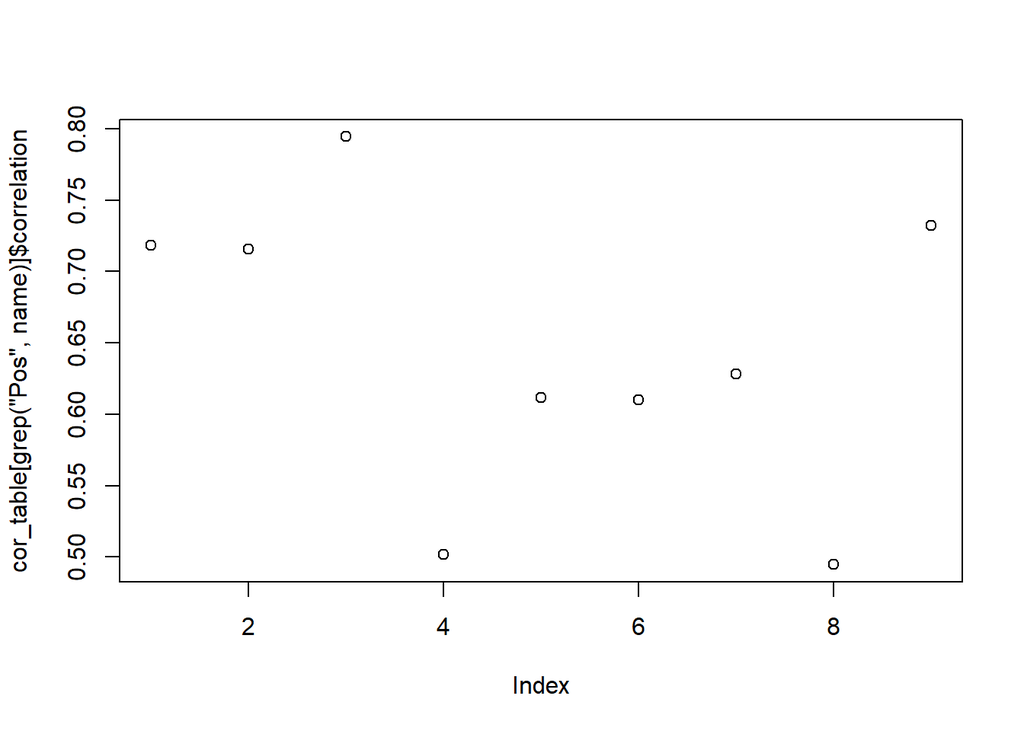

**Condition: Negative Frame**

Range and dotplot

[output not shown]

[figure not shown]

## First Look at Data

Boxplots can be a great way to get an overview over the data. Black line indicates Median, blue boxes indicate interquartiles, whiskers indicate values outside the box and points indicate outliers. Trust and Confidence Items are rated on a Likert 1-7 scale, whereas Transfer Items are rated on a Likert 0-10 scale.

**All Items**

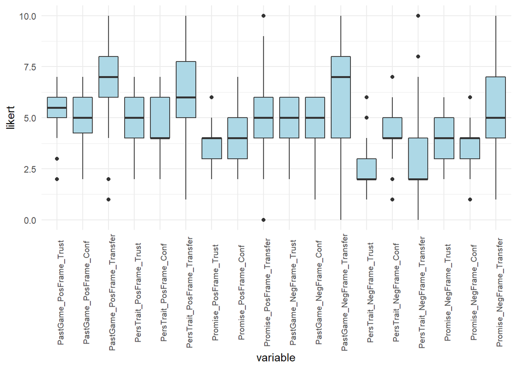

**Trust Items**

Trust items were rated on a Likert 1-7 scale. The following characteristics can be identified:

1. In the positive frame, the promise item seems the least trustworthy. This was to be expected from the previous literature.
2. In the negative frame, the personality trait item was the least trustworthy. This was not to be expected from previous literature.
3. The personality trait item differs the most between positive and negative frame. Limitations: This could be due to incorrect wording.
4. Framing does not seem to have too much impact on the perception of the trustworthiness of a person. No big differences can be found between past game items in both frames. The same applies to the promise item. The personality trait item differs between the frames, but this could be rather be due to misleading item formulation.

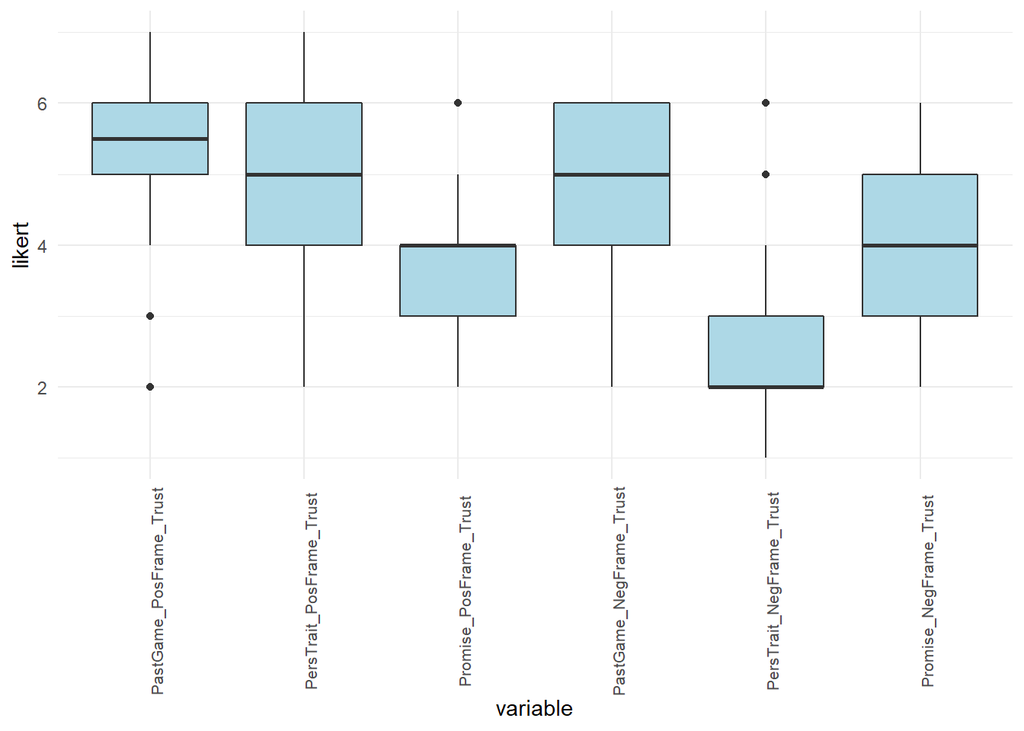

**Confidence Items**

Condidence items were rated on a Likert 1-7 scale. The following characteristics can be identified:

1. The confidence in ones decision to invest money in someone seems to be quite stable over the different items.
2. Framing does not seem to have an impact on confidence.
3. The confidence in promise items might be slightly lower than in the others.

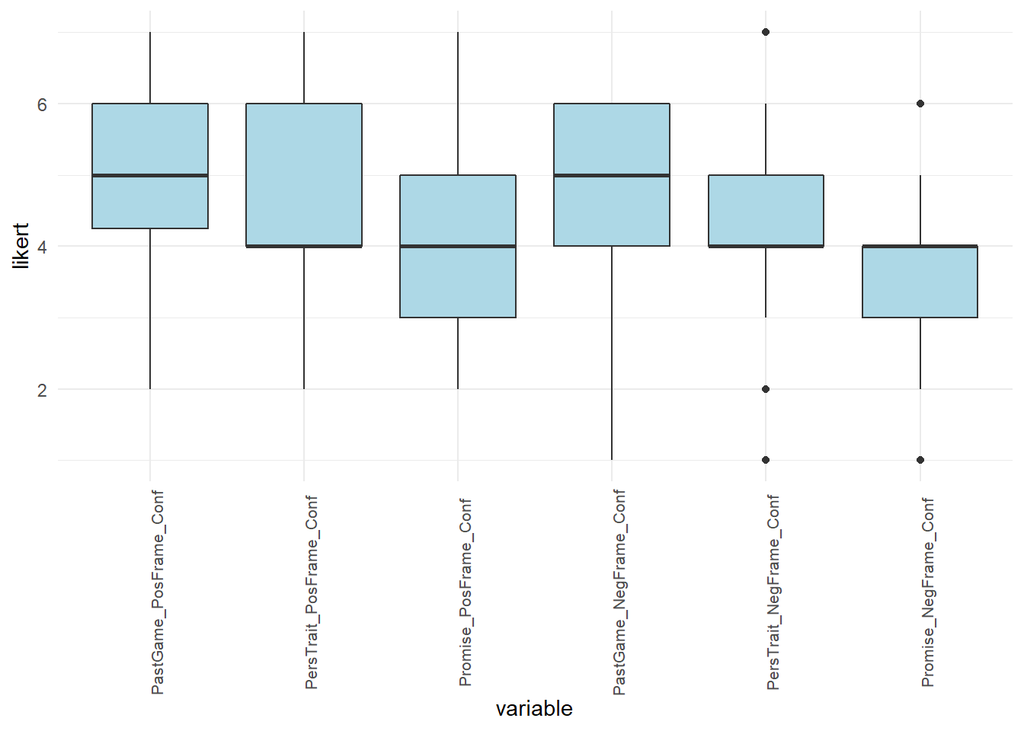

**Transfer Items**

Transfer items were rated on a Likert 0-10 scale. The following characteristics can be identified:

1. Most of the medians lie between an investment of 5.0 Fr. and 7.5 Fr. This does not apply to the personality trait item in the negative frame. Possible reason is incorrect wording
2. Medians of the positive frame and the negative frame were quite similar (except in the personality trait item). This means, that framing does not have an impact on the amount invested.
3. Money transfer is item dependent. People tend to invest the least amount on the promise item, more on the personality trait item and the most on the past game item.

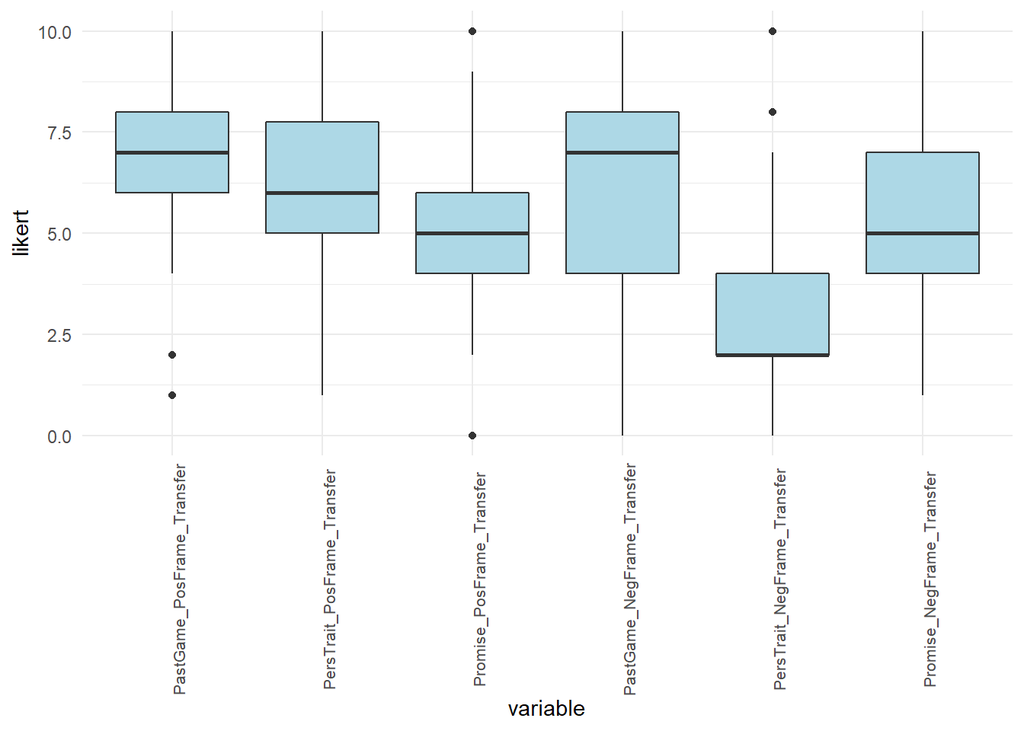

**Correlation Table**

Correlation Networks are a great way to visualize connections between items. However, they can only be interpreted by considering the corresponding correlation matrix.

Correlation matrix for positive frame:

```
##                             PastGame_PosFrame_Trust PastGame_PosFrame_Conf
## PastGame_PosFrame_Trust                  1.00000000            0.305541324
## PastGame_PosFrame_Conf                   0.30554132            1.000000000
## PastGame_PosFrame_Transfer               0.50946477            0.332444057
## PersTrait_PosFrame_Trust                 0.42199212            0.123363624
## PersTrait_PosFrame_Conf                  0.26103782            0.546160892
## PersTrait_PosFrame_Transfer              0.38387747            0.087364655
## Promise_PosFrame_Trust                   0.24820258            0.183469629
## Promise_PosFrame_Conf                    0.11582079            0.519375724
## Promise_PosFrame_Transfer                0.09207535           -0.003454423
##                             PastGame_PosFrame_Transfer PersTrait_PosFrame_Trust
## PastGame_PosFrame_Trust                     0.50946477                0.4219921
## PastGame_PosFrame_Conf                      0.33244406                0.1233636
## PastGame_PosFrame_Transfer                  1.00000000                0.2164900
## PersTrait_PosFrame_Trust                    0.21648999                1.0000000
## PersTrait_PosFrame_Conf                     0.18912835                0.4106665
## PersTrait_PosFrame_Transfer                 0.55625432                0.6025119
## Promise_PosFrame_Trust                      0.09665079                0.2519055
## Promise_PosFrame_Conf                       0.07458442                0.1472044
## Promise_PosFrame_Transfer                   0.27629284                0.1528627
##                             PersTrait_PosFrame_Conf PersTrait_PosFrame_Transfer
## PastGame_PosFrame_Trust                  0.26103782                  0.38387747
## PastGame_PosFrame_Conf                   0.54616089                  0.08736465
## PastGame_PosFrame_Transfer               0.18912835                  0.55625432
## PersTrait_PosFrame_Trust                 0.41066646                  0.60251189
## PersTrait_PosFrame_Conf                  1.00000000                  0.40723537
## PersTrait_PosFrame_Transfer              0.40723537                  1.00000000
## Promise_PosFrame_Trust                   0.05169477                  0.21728447
## Promise_PosFrame_Conf                    0.66127659                  0.01006266
## Promise_PosFrame_Transfer               -0.11340139                  0.41106192
##                             Promise_PosFrame_Trust Promise_PosFrame_Conf
## PastGame_PosFrame_Trust                 0.24820258            0.11582079
## PastGame_PosFrame_Conf                  0.18346963            0.51937572
## PastGame_PosFrame_Transfer              0.09665079            0.07458442
## PersTrait_PosFrame_Trust                0.25190554            0.14720437
## PersTrait_PosFrame_Conf                 0.05169477            0.66127659
## PersTrait_PosFrame_Transfer             0.21728447            0.01006266
## Promise_PosFrame_Trust                  1.00000000            0.11447096
## Promise_PosFrame_Conf                   0.11447096            1.00000000
## Promise_PosFrame_Transfer               0.67160728            0.03423172
##                             Promise_PosFrame_Transfer
## PastGame_PosFrame_Trust                   0.092075354
## PastGame_PosFrame_Conf                   -0.003454423
## PastGame_PosFrame_Transfer                0.276292842
## PersTrait_PosFrame_Trust                  0.152862658
## PersTrait_PosFrame_Conf                  -0.113401389
## PersTrait_PosFrame_Transfer               0.411061916
## Promise_PosFrame_Trust                    0.671607276
## Promise_PosFrame_Conf                     0.034231720
## Promise_PosFrame_Transfer                 1.000000000
```

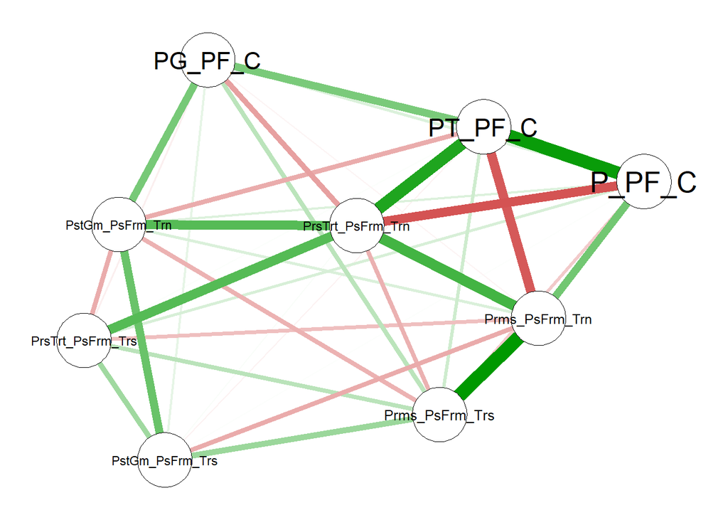

Item description:

- PG & PstGm = Past Game; PT & PrsTrt = Personality Trait; P & Prms = Promise
- C = Confidence; Trn = Transfer; Trs = Trust

Correlation matrix for negative frame:

```
##                             PastGame_NegFrame_Trust PastGame_NegFrame_Conf
## PastGame_NegFrame_Trust                  1.00000000              0.4551613
## PastGame_NegFrame_Conf                   0.45516131              1.0000000
## PastGame_NegFrame_Transfer               0.74843718              0.3963697
## PersTrait_NegFrame_Trust                 0.03982418              0.2289963
## PersTrait_NegFrame_Conf                  0.16877592              0.3680650
## PersTrait_NegFrame_Transfer              0.09308735              0.2261898
## Promise_NegFrame_Trust                   0.10008315              0.1369550
## Promise_NegFrame_Conf                    0.06943240              0.2762711
## Promise_NegFrame_Transfer                0.39419091              0.2392748
##                             PastGame_NegFrame_Transfer PersTrait_NegFrame_Trust
## PastGame_NegFrame_Trust                     0.74843718               0.03982418
## PastGame_NegFrame_Conf                      0.39636966               0.22899626
## PastGame_NegFrame_Transfer                  1.00000000               0.09755806
## PersTrait_NegFrame_Trust                    0.09755806               1.00000000
## PersTrait_NegFrame_Conf                     0.17167704              -0.18316423
## PersTrait_NegFrame_Transfer                 0.23223206               0.67332970
## Promise_NegFrame_Trust                      0.12181019               0.05417500
## Promise_NegFrame_Conf                       0.10375830               0.21711858
## Promise_NegFrame_Transfer                   0.61025896               0.09982245
##                             PersTrait_NegFrame_Conf PersTrait_NegFrame_Transfer
## PastGame_NegFrame_Trust                   0.1687759                  0.09308735
## PastGame_NegFrame_Conf                    0.3680650                  0.22618975
## PastGame_NegFrame_Transfer                0.1716770                  0.23223206
## PersTrait_NegFrame_Trust                 -0.1831642                  0.67332970
## PersTrait_NegFrame_Conf                   1.0000000                 -0.15488285
## PersTrait_NegFrame_Transfer              -0.1548829                  1.00000000
## Promise_NegFrame_Trust                   -0.2210479                  0.09272539
## Promise_NegFrame_Conf                     0.2617560                  0.14442830
## Promise_NegFrame_Transfer                -0.1328558                  0.35184163
##                             Promise_NegFrame_Trust Promise_NegFrame_Conf
## PastGame_NegFrame_Trust                 0.10008315            0.06943240
## PastGame_NegFrame_Conf                  0.13695497            0.27627112
## PastGame_NegFrame_Transfer              0.12181019            0.10375830
## PersTrait_NegFrame_Trust                0.05417500            0.21711858
## PersTrait_NegFrame_Conf                -0.22104791            0.26175603
## PersTrait_NegFrame_Transfer             0.09272539            0.14442830
## Promise_NegFrame_Trust                  1.00000000            0.03066289
## Promise_NegFrame_Conf                   0.03066289            1.00000000
## Promise_NegFrame_Transfer               0.57899819            0.12857873
##                             Promise_NegFrame_Transfer
## PastGame_NegFrame_Trust                    0.39419091
## PastGame_NegFrame_Conf                     0.23927484
## PastGame_NegFrame_Transfer                 0.61025896
## PersTrait_NegFrame_Trust                   0.09982245
## PersTrait_NegFrame_Conf                   -0.13285579
## PersTrait_NegFrame_Transfer                0.35184163
## Promise_NegFrame_Trust                     0.57899819
## Promise_NegFrame_Conf                      0.12857873
## Promise_NegFrame_Transfer                  1.00000000
```

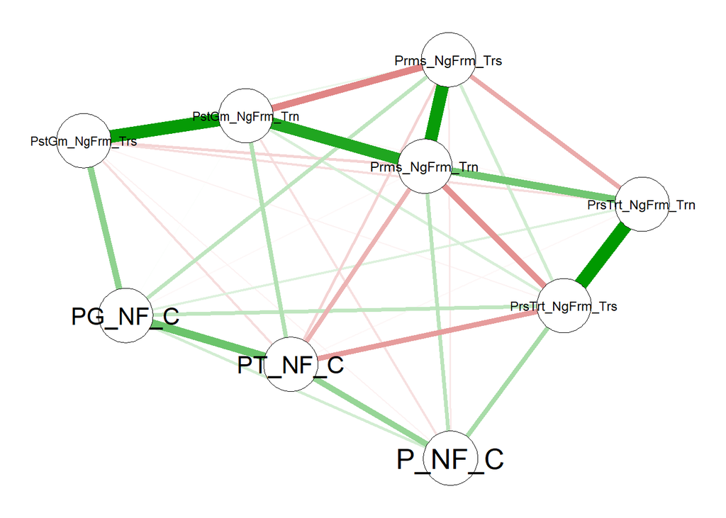

Item description:

- PG & PstGm = Past Game; PT & PrsTrt = Personality trait; P & Prms = Promise
- C = Confidence; Trn = Transfer; Trs = Trust

## Hypothesis Testing

### Did Framing work?

```
##                                var1                             var2 w.stat
## 1:     data$PastGame_PosFrame_Trust     data$PastGame_NegFrame_Trust 1470.5
## 2:      data$PastGame_PosFrame_Conf      data$PastGame_NegFrame_Conf 1579.0
## 3:  data$PastGame_PosFrame_Transfer  data$PastGame_NegFrame_Transfer 1361.0
## 4:      data$Promise_PosFrame_Trust      data$Promise_NegFrame_Trust 1247.0
## 5:       data$Promise_PosFrame_Conf       data$Promise_NegFrame_Conf 1604.0
## 6:   data$Promise_PosFrame_Transfer   data$Promise_NegFrame_Transfer 1258.5
## 7:    data$PersTrait_PosFrame_Trust    data$PersTrait_NegFrame_Trust 2296.5
## 8:     data$PersTrait_PosFrame_Conf     data$PersTrait_NegFrame_Conf 1523.5
## 9: data$PersTrait_PosFrame_Transfer data$PersTrait_NegFrame_Transfer 2156.5
##    p.value p.adjust
## 1:  0.3019   1.0000
## 2:  0.0798   0.4788
## 3:  0.8020   1.0000
## 4:  0.5989   1.0000
## 5:  0.0545   0.3815
## 6:  0.6680   1.0000
## 7:  0.0000   0.0000
## 8:  0.1691   0.8455
## 9:  0.0000   0.0000
```

### How did subjects rate the different information types?

Different types of information are considered to be perceived differently by subjects. This has never been further investigated in past research making this an exploratory hypothesis. It is being expected that past experience is perceived the most useful followed by information on personality trait and then the promised message (PersMess). Nonparametric friedman test is performed on the ordinal data at hand. It is followed by bonferroni corrected paired wilcox post-hoc tests. In advance it was checked whether there are significant differences between positive and negative condition, which was not the case. Therefore friedman test was calculated over both conditions together. The three items do in fact differ significantly:

```
##
##  Friedman rank sum test
##
## data:  data_friedman_long$value, data_friedman_long$variable and data_friedman_long$id
## Friedman chi-squared = 41.263, df = 2, p-value = 1.096e-09
```

```
##                    Min. 1st Qu. Median     Mean 3rd Qu. Max.
## PosFrame_PastBehav    1       3      5 4.703704       6    7
## PosFrame_PersTrait    1       3      4 3.944444       5    7
## PosFrame_PersMess     1       2      3 3.444444       4    7
## NegFrame_PastBehav    1       5      6 5.163265       6    7
## NegFrame_PersTrait    1       3      4 3.877551       5    7
## NegFrame_PersMess     1       3      3 3.632653       5    7
```

```
## # A tibble: 3 x 9
##   .y.   group1    group2       n1    n2 statistic        p    p.adj p.adj.signif
## * <chr> <chr>     <chr>     <int> <int>     <dbl>    <dbl>    <dbl> <chr>
## 1 value UsefulPa~ UsefulPe~   103   103      2928  1.82e-9  5.46e-9 ****
## 2 value UsefulPa~ UsefulPe~   103   103      2290  8.08e-7  2.42e-6 ****
## 3 value UsefulPe~ UsefulPe~   103   103      1205  4.30e-2  1.30e-1 ns
```

### Is there a relationship between Trust and the perceived usefulness?

It is assumed, that the there is a relationship between the trust items and the usefulness items. When an information type is perceived useful for a person, it will also be perceived trustworthy. No significant differences can be found between positive and negative frames of the trust items (except for the personality trait item, which is due to poor item formulation). Therefore it is not necessary to test the two conditions separately. The test of choice was a correlation test. Spearman method was used, since data is ordinal scaled. Results can be found below:

**Past Game**

```
##
##  Spearman's rank correlation rho
##
## data:  data$PastGame_Trust and data$UsefulPastBehav
## S = 82551, p-value = 2.316e-09
## alternative hypothesis: true rho is not equal to 0
## sample estimates:
##       rho
## 0.5466795
```

**Personality trait**

```
##
##  Spearman's rank correlation rho
##
## data:  data$PersTrait_Trust and data$UsefulPersTrait
## S = 174111, p-value = 0.6598
## alternative hypothesis: true rho is not equal to 0
## sample estimates:
##        rho
## 0.04389439
```

**Promise**

```
##
##  Spearman's rank correlation rho
##
## data:  data$Promise_Trust and data$UsefulPersMess
## S = 127787, p-value = 0.002212
## alternative hypothesis: true rho is not equal to 0
## sample estimates:
##       rho
## 0.2982762
```